# Calidad de Agua de Ríos de Panamá: Compendio de Laboratorio 2002–2024

Documentación del conjunto de datos tidy

Santamaría, Andrés — Universidad Tecnológica de Panamá

2026-03-11

# 1 Descripción general

El dataset fue procesado desde los archivos fuente de formato *wide* (estaciones como bloques de filas, campañas de muestreo como columnas) a formato *tidy* (una fila por observación), corrigiendo 23 tipos de anomalías documentadas en los Excels originales.

**Acceso al dataset:**  
> Santamaría, A. (2026). *Calidad de agua de ríos de Panamá: Compendio de laboratorio 2002–2024* [Data set]. Zenodo. https://doi.org/10.5281/zenodo.18945787

**Fuente original:**  
> Ministerio de Ambiente de Panamá. (2025). *Registros históricos de índice de calidad de agua 2022–2023*. SINIA. https://sinia.gob.pa/registros-historicos-de-indice-de-calidad-de-agua-2022-2023/

# 2 Cobertura

## 2.1 Espacio-temporal

| Provincia / Comarca | Tipo | Observaciones | Estaciones | Año inicio | Año fin | % con coords |
| --- | --- | --- | --- | --- | --- | --- |
| Comarca Göbe Bugle | Comarca | 121 | 3 | 2003 | 2023 | 100.0 |
| Comarca Kuna Yala | Comarca | 48 | 3 | 2003 | 2017 | 100.0 |
| Bocas del Toro | Provincia | 297 | 3 | 2002 | 2022 | 100.0 |
| Chiriquí | Provincia | 661 | 7 | 2003 | 2023 | 100.0 |
| Coclé | Provincia | 414 | 3 | 2002 | 2023 | 100.0 |
| Colón | Provincia | 347 | 3 | 2003 | 2024 | 100.0 |
| Darién | Provincia | 153 | 5 | 2002 | 2022 | 96.7 |
| Herrera | Provincia | 442 | 8 | 2002 | 2022 | 100.0 |
| Los Santos | Provincia | 594 | 3 | 2002 | 2022 | 96.3 |
| Panamá Este | Provincia | 119 | 3 | 2003 | 2023 | 100.0 |
| Panamá Metropolitana | Provincia | 633 | 4 | 2002 | 2023 | 95.4 |
| Panamá Oeste | Provincia | 530 | 9 | 2002 | 2023 | 99.1 |
| Veraguas | Provincia | 583 | 6 | 2003 | 2022 | 100.0 |

## 2.2 Mapa de estaciones

[interactive chart not shown]

# 3 Estructura del archivo

El archivo `laboratorio_tidy_v5.csv` contiene **4,942 filas** y **53 columnas** codificadas en UTF-8, sin BOM, con `NA` representados por cadena vacía.

## 3.1 Columnas de identificación (8)

| Columna | Tipo | Descripción |
| --- | --- | --- |
| `provincia` | chr | Provincia o comarca (13 valores únicos) |
| `division_admin` | chr | `"Provincia"` o `"Comarca"` |
| `station_id` | chr | Identificador único generado: `PROVCODE_CXXX_NOMBRE_ESTACION` |
| `station_code` | chr | Código original del Excel (`"Estación 1"`, etc.) |
| `station_name` | chr | Nombre descriptivo de la estación |
| `rio_cuenca` | chr | Nombre del río y número de cuenca hidrográfica (ej. `"Río San San (Cuenca 89)"`) |
| `lat` | dbl | Latitud WGS84 (grados decimales); **98.8 %** de filas con valor |
| `lon` | dbl | Longitud WGS84 (grados decimales) |

## 3.2 Columnas temporales (3)

| Columna | Tipo | Descripción |
| --- | --- | --- |
| `date` | chr | Fecha de muestreo en formato `YYYY-MM-DD`; `NA` para promedios estacionales |
| `anio` | int | Año del muestreo (2002–2024) |
| `temporada` | chr | `"Seca"` o `"Lluviosa"` |

## 3.3 Columnas de parámetros fisicoquímicos y bacteriológicos (20)

| Columna | Unidad | n | Mediana | Rango real |
| --- | --- | --- | --- | --- |
| `pH` | — | 4,912 | 7.57 | 3.6 – 12 |
| `temp_C` | °C | 4,915 | 26.6 | 2.8 – 35.6 |
| `conductividad` | mS/m | 4,442 | 23.8 | 0.5 – 390,000 |
| `turbidez_NTU` | NTU | 4,293 | 9.9 | 0 – 1,120 |
| `OD_mgL` | mg/L | 4,772 | 7.0 | 0 – 24 |
| `OD_sat_mgL` | mg/L | 4,600 | 8.0 | 1.8 – 12.8 |
| `OD_pct_sat` | % | 4,719 | 85.4 | 0 – 158 |
| `DOD_mgL` | mg/L | 673 | 1.1 | −2.9 – 13.8 |
| `DBO_mgL` | mg/L | 4,543 | 2.0 | 0 – 20,800 |
| `solidos_totales_mgL` | mg/L | 4,717 | 145 | 0 – 41,800 |
| `solidos_suspendidos_mgL` | mg/L | 4,648 | 8.9 | 0 – 37,600 |
| `solidos_disueltos_mgL` | mg/L | 4,150 | 119 | 0 – 41,800 |
| `NO3_mgL` | mg/L | 4,722 | 1.2 | 0 – 4,150 |
| `PO4_mgL` | mg/L | 3,988 | 0.16 | 0 – 900 |
| `PT_mgL` | mg/L | 625 | 0.10 | 0 – 2,420 |
| `SO4_mgL` | mg/L | 32 | 2.7 | 0.1 – 35.3 |
| `coliformes_fecales` | UFC/100mL o NMP/100mL | 4,304 | 500 | 0 – 177,000,000 |
| `coliformes_totales` | UFC/100mL o NMP/100mL | 4,745 | 3,300 | 0 – 525,000,000 |
| `ecoli` | UFC/100mL | 502 | 740 | 0 – 65,100,000 |
| `ICA` | 0–100 | 4,765 | 72 | 8 – 97 |

> **Nota sobre `conductividad`:** los valores >5,000 mS/m están flaggeados como `conductividad_extrema` en la columna `observaciones`. Algunos corresponden a estaciones estuarinas (bocas de río, Bocas del Toro y Panamá Este) y son físicamente reales; otros (Veraguas interior, “Cantera San Pablo” con 390,000 mS/m) son posiblemente errores de unidades o impacto de actividad minera.

## 3.4 Columna de método de coliformes (1)

| Columna | Valores | Descripción |
| --- | --- | --- |
| `coliformes_metodo` | `UFC`, `NMP`, `NMP/UFC` | Método de cuantificación de coliformes para esa campaña. `NMP/UFC` indica que en el mismo bloque aparecen filas de ambos métodos. |

## 3.5 Columnas de censura (20)

Por cada parámetro numérico existe una columna `<param>_censado` que contiene el **operador de censura** tal como fue registrado en el Excel original, o vacío si el valor es directamente medido.

| Flag | n | Significado |
| --- | --- | --- |
| `<LD` | 2,719 | Menor al límite de detección del método analítico |
| `<` | 2,429 | Menor a un umbral declarado (ej. `< 2`) |
| `>` | 405 | Mayor a un umbral declarado (ej. `> 2,000`) |
| `<=` | 60 | Menor o igual a un umbral |
| `>=` | 19 | Mayor o igual a un umbral |
| `*` | 16 | Muestra fuera de holding time (ver `observaciones`) |
| `rango` | 5 | Valor original era un rango (ej. `7.35–7.40`); se usó el promedio |

**Total flags de censura: 5,653**

Los parámetros más censurados son DBO_mgL (1,387), turbidez_NTU (553), coliformes_totales (499), NO3_mgL (497) y sólidos_suspendidos_mgL (432).

## 3.6 Columna de observaciones (1)

La columna `observaciones` es texto libre que puede contener uno o más de los siguientes flags separados por `"; "`:

[output not shown]

# 4 Anomalías en los archivos fuente

Durante el procesamiento se identificaron y corrigieron **23 tipos de anomalías** en los 13 archivos Excel originales. Se documentan aquí para transparencia y reproducibilidad.

## 4.1 Anomalías de valores

| # | Tipo | Provincias afectadas | Corrección aplicada |
| --- | --- | --- | --- |
| 1 | Censuras `< > ≥ ≤` en celdas de valor | Todas | Extraídas a columnas `_censado`; valor numérico limpiado |
| 2 | Asteriscos sufijo (`0.6*`, `3400*`) | Kuna Yala, Panamá Oeste | Extraídos a flag `*` en `_censado` |
| 3 | `<LD`, `<L.D.`, `ND`, `NM`, `NPI`, `NC` | Todas | Flag `<LD`; valor → `NA` |
| 4 | Negativos en NO₃, PO₄, OD%sat | Coclé, Herrera | → `NA` |
| 5 | Comas europeas como separador decimal (`1,02`) | Chiriquí, Los Santos, Colón, Herrera | → `.` antes de `as.numeric()` |
| 6 | OD_sat > 20 mg/L; OD%sat > 200% | Coclé, Los Santos, Herrera | → `NA` |
| 7 | Conductividad < 0.5 mS/m | Varias | → `NA` (valores centinela de cero) |
| 8 | ICA expresado como fracción (0–1 en lugar de 0–100) | Los Santos | → × 100 |
| 9 | Coliformes con decimales | Varias | → `round(..., 0)` |
| 10 | DOD > 20: probable mezcla con columna OD%sat | Bocas del Toro | → `NA` + flag |
| 11 | pH > 14 o ICA > 100 | Herrera, Darién | → `NA` + flag |
| 12 | Doble punto (`0..18`) | Varias | → `0.18` |
| 13 | Unicode menos (`−` en lugar de `-`) | Veraguas | → `-` estándar ASCII |
| 14 | `#REF!` en celdas de fórmula | Herrera | → `NA` |
| 15 | `? 2,50` (signo de interrogación) | Veraguas | Parte numérica extraída |
| 16 | Rangos en celda (`7.35–7.40`) | Panamá Metropolitana | → promedio; rango original en `observaciones` |
| 17 | Coliformes > 10⁷ sin censura | Panamá Metropolitana, Panamá Oeste | Flag en `observaciones` |

## 4.2 Anomalías de fechas

| # | Tipo | Ejemplo | Corrección |
| --- | --- | --- | --- |
| 18 | Celda “Promedio” en lugar de fecha | `"Promedio"` | `date = NA`; flag `dato_promediado_por_miambiente` |
| 19 | Celda vacía con temporada estacional | (vacío) | Mismo tratamiento que #18 |
| 20 | Errores tipográficos de año | `01/09/02008` → 2008 | Corrección por regex |
| 21 | Fecha serial de Excel | `42619.0` | → `as.Date(..., origin="1899-12-30")` |

## 4.3 Anomalías de coordenadas

| # | Tipo | Ejemplo | Corrección |
| --- | --- | --- | --- |
| 22 | Inversión N/E (`1032079 N/ 329564 E`) | Bocas del Toro | Detección automática por patrón `E.{0,5}/` |
| 23 | Zona UTM incorrecta | Chiriquí, Bocas (easting ~330k en Z18N → lon −76°) | Auto-detect: Z17N primero; si fuera del bbox de Panamá, Z18N |

# 5 Distribución del ICA

El **Índice de Calidad del Agua (ICA)** de MIAMBIENTE es una puntuación compuesta de 0 a 100 que integra los principales parámetros fisicoquímicos y bacteriológicos.

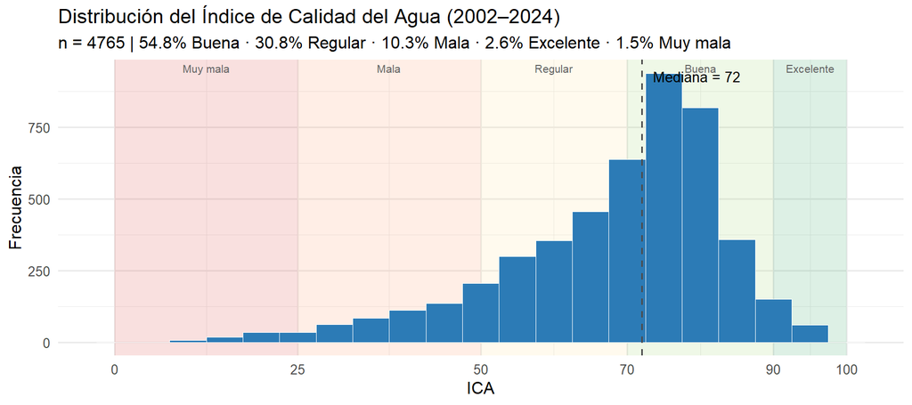

## 5.1 ICA por provincia

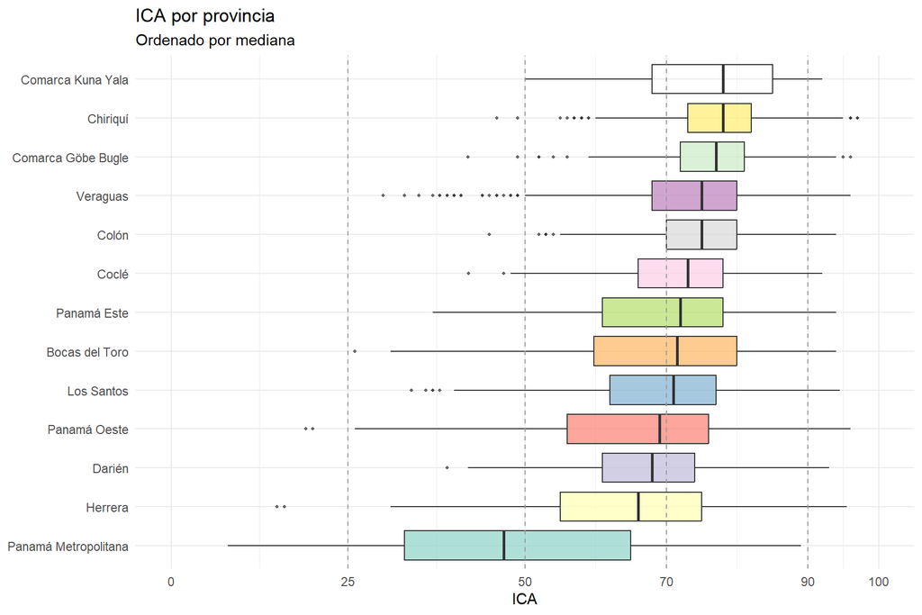

## 5.2 Tendencia temporal del ICA

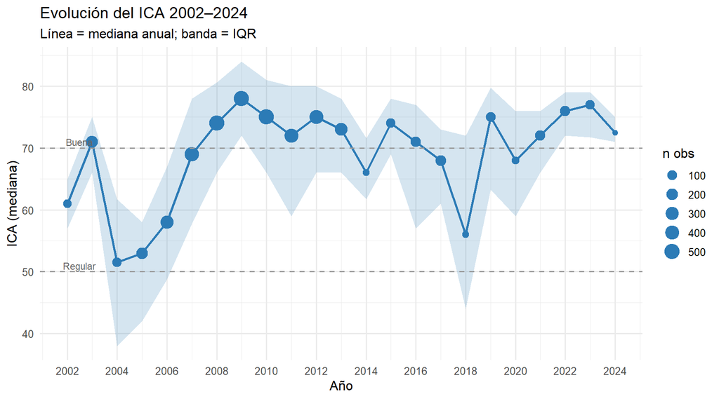

# 6 Coliformes fecales

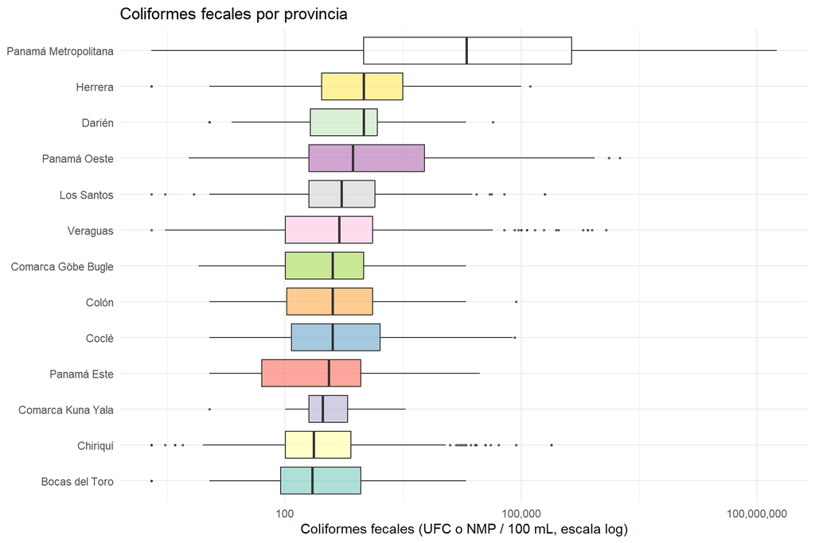

# 7 Banderas de calidad (QA flags)

| Flag en `observaciones` | n | Acción sobre valor |
| --- | --- | --- |
| dato_promediado_por_miambiente | 1247 | date = NA; valor conservado |
| muestra_fuera_de_holding_time | 7 | valor conservado |
| posible_error_calibracion_sonda | 49 | valor conservado |
| dod_posible_mezcla_con_od_pct | 11 | DOD → NA |
| valor_fisicamente_imposible | 4 | pH o ICA → NA |
| temperatura_sospechosa | 6 | valor conservado |
| dbo_extremo | 6 | valor conservado |
| conductividad_extrema | 74 | valor conservado |
| coliforme_fecal_extremo_sin_flag | 10 | valor conservado |
| coliforme_total_extremo_sin_flag | 8 | valor conservado |

Para filtrar filas con una bandera específica:

```r
# Solo mediciones directas (excluir promedios estacionales)
mediciones <- df |> filter(!str_detect(replace_na(observaciones,""),
                                        "dato_promediado"))

# Solo datos con fechas válidas y sin banderas de calidad
datos_limpios <- df |>
  filter(!is.na(date)) |>
  filter(is.na(observaciones) |
         !str_detect(observaciones,
                     "posible_error|fisicamente_imposible|dod_posible_mezcla"))
```

# 8 Reproducibilidad

El dataset fue generado con el script `limpiar_laboratorio_v5.R` incluido en este repositorio. Para reproducirlo:

```r
# Requisitos
install.packages(c("tidyverse","readxl","zip","lubridate"))

# Ejecutar
source("limpiar_laboratorio_v5.R")
# → genera laboratorio_tidy_v5.csv en C:/Users/andre/
```

**Entorno de desarrollo:**

```
## R 4.5.2 ([Not] Part in a Rumble)
## tidyverse 2.0.0
## readxl    1.4.5
```

# 9 Citas

**Para citar la fuente original:**

> Ministerio de Ambiente de Panamá. (2025). *Registros históricos de índice de calidad de agua 2022–2023*. SINIA. https://sinia.gob.pa/registros-historicos-de-indice-de-calidad-de-agua-2022-2023/

*Generado automáticamente con `rmarkdown::render("README.Rmd")`.*